# Linear Models and Their Generalizations

Chapter 2: Validation and selection model

Katia Meziani

# 1. Multivariate linear gaussian regression model

## 1.1. The data set Ozone

```r
library(rmarkdown)
library(dplyr)
ozone1 <- read.table("ozone1.txt",header=TRUE, sep="", dec=",")
ozone1$Date <- as.Date(as.factor(ozone1$Date),format = "%Y%m%d")
ozone1$vent<-as.factor(ozone1$vent)
ozone1$pluie<-as.factor(ozone1$pluie)
ozone1 <- ozone1 %>% mutate(across(where(is.character), as.numeric))
ozone1 <- ozone1 %>% mutate(across(where(is.integer), as.numeric))
ozone1  <- ozone1  %>% arrange(Date)
Ozone<-ozone1[,2:12]
paged_table(Ozone)
```

| maxO3 | T9 | T12 | T15 | Ne9 | Ne12 | Ne15 | Vx9 | Vx12 | Vx15 | maxO3v |
| --- | --- | --- | --- | --- | --- | --- | --- | --- | --- | --- |
| 87 | 15.6 | 18.5 | 18.4 | 4 | 4 | 8 | 0.6946 | -1.7101 | -0.6946 | 84 |
| 82 | 17.0 | 18.4 | 17.7 | 5 | 5 | 7 | -4.3301 | -4.0000 | -3.0000 | 87 |
| 92 | 15.3 | 17.6 | 19.5 | 2 | 5 | 4 | 2.9544 | 1.8794 | 0.5209 | 82 |
| 114 | 16.2 | 19.7 | 22.5 | 1 | 1 | 0 | 0.9848 | 0.3473 | -0.1736 | 92 |
| 94 | 17.4 | 20.5 | 20.4 | 8 | 8 | 7 | -0.5000 | -2.9544 | -4.3301 | 114 |
| 80 | 17.7 | 19.8 | 18.3 | 6 | 6 | 7 | -5.6382 | -5.0000 | -6.0000 | 94 |
| 79 | 16.8 | 15.6 | 14.9 | 7 | 8 | 8 | -4.3301 | -1.8794 | -3.7588 | 80 |
| 79 | 14.9 | 17.5 | 18.9 | 5 | 5 | 4 | 0.0000 | -1.0419 | -1.3892 | 99 |
| 101 | 16.1 | 19.6 | 21.4 | 2 | 4 | 4 | -0.7660 | -1.0261 | -2.2981 | 79 |
| 106 | 18.3 | 21.9 | 22.9 | 5 | 6 | 8 | 1.2856 | -2.2981 | -3.9392 | 101 |

[output cut: 102 more lines]

## 1.2. Train/Test Split

We split our dataset into two parts: 80% for training and 20% for testing. This separation allows us to evaluate the performance of our model on unseen data, ensuring that our model’s quality and generalization capabilities are assessed on a separate subset of data that it has not been exposed to during training

Here is a classic random split.

```r
set.seed(1234)
ozone_split    <- rsample::initial_split(Ozone, prop = 0.8)
train<- rsample::training(ozone_split)
test <- rsample::testing(ozone_split)
```

In the case of data collected over several consecutive days (our setting), this type of train/test split can introduce biases, especially if the measurements are time-correlated. In this case, it is better to perform a chronological split, meaning using the earlier observations for training and the later ones for testing.

```r
train_size <- floor(0.8 * nrow(Ozone))

train <- Ozone[1:train_size, ]
test <- Ozone[(train_size + 1):nrow(Ozone), ]
```

## 1.3. Declaration of the model

**The multivariate linear gaussian regression model.** Let $(Y_i,x_i)_{i=1,\cdots,n}$, we define the simple linear gaussian model as follows
$$Y_i=\beta_0+\beta_1x_{i1}+\cdots+\beta_px_{ip}+\epsilon_i,\quad
i=1,\cdots,n\Leftrightarrow \mathbf{Y}=\mathbb{X}\boldsymbol{\beta}+\boldsymbol{\epsilon}$$
where the following **Assumptions** are satisfied:

- **[P1]:** The $\epsilon_i$ are centered.
- **[P2]:** The $\epsilon_i$ have a constant variance (noise level) $\sigma^2>0$ (*homoscedasticity*).
- **[P3]:** The $\epsilon_i$ are uncorrelated.
- **[P4]:** The $\epsilon_i$ are Gaussian.

These assumptions can be summarized as $\boldsymbol{\epsilon} \sim \mathcal{N}(\boldsymbol{0}_n, \sigma^2\mathbf{I}_n)$.

**Ⓡ** Declare our model `mod`and display the `summary`.

```r
mod<-lm(maxO3~.,data=train)
summary(mod)
```

```
##
## Call:
## lm(formula = maxO3 ~ ., data = train)
##
## Residuals:
##     Min      1Q  Median      3Q     Max
## -52.549  -9.834  -0.017   7.327  40.358
##
## Coefficients:
##             Estimate Std. Error t value Pr(>|t|)
## (Intercept) 15.52017   17.96112   0.864   0.3902
## T9           0.64485    1.64697   0.392   0.6965
## T12          1.12712    1.83010   0.616   0.5398
## T15          0.92755    1.35258   0.686   0.4949
## Ne9         -2.51568    1.13422  -2.218   0.0295 *
## Ne12        -0.60043    1.57842  -0.380   0.7047
## Ne15         0.58109    1.23883   0.469   0.6403
## Vx9          1.62026    1.23708   1.310   0.1941
## Vx12        -0.15646    1.34668  -0.116   0.9078
## Vx15         0.31366    1.11303   0.282   0.7788
## maxO3v       0.35796    0.07316   4.893 5.23e-06 ***
## ---
## Signif. codes:  0 '***' 0.001 '**' 0.01 '*' 0.05 '.' 0.1 ' ' 1
##
## Residual standard error: 15.72 on 78 degrees of freedom
## Multiple R-squared:  0.748,  Adjusted R-squared:  0.7157
## F-statistic: 23.16 on 10 and 78 DF,  p-value: < 2.2e-16
```

# 2. Model validation

## 2.1. Overview of Residuals

It is important to check that these assumptions are verified on our data, which means validating the 4 assumptions. Since we do not have access to the theoretical residuals $\epsilon=(\epsilon_1,\ldots,\epsilon_n)^\top$, we will validate the assumptions based on the **estimated residuals**. By theorem of chapter 1,
$$\widehat{\epsilon}=Y-\widehat{Y}=(\mathbf{I}_n-P_X)Y=P_{X^\perp}Y\sim\mathcal{N}(\boldsymbol{0}_n,\sigma^2P_{X^\perp})$$

**Ⓡ** Display the `summary of the residuals

```r
summary(residuals(mod))
```

```
##     Min.  1st Qu.   Median     Mean  3rd Qu.     Max.
## -52.5489  -9.8341  -0.0173   0.0000   7.3266  40.3580
```

✍ Let denote by $h_{ij}$ the element of the projector $P_X$, such that
$$P_X=\big[h_{ij}\big]_{1\leq i\leq n\\ 1\leq j\leq n}\quad
\text{and}\quad
P_{X^\perp}=\mathbf{I}_n-P_X=\big[\mathbb{1}_{i=j}-h_{ij}\big]_{1\leq
i\leq n\\ 1\leq j\leq n}$$

📝 If **[P1]** is statisfied by $\epsilon=(\epsilon_1,\ldots,\epsilon_n)^\top\,$, (*i.e* $\text{E}_\beta[\epsilon_i]=0$), the **estimated residuals** also satisfy $\text{E}_\beta[\widehat{\epsilon_i}]=0$.

📝 If **[P2]** (homoscedasticity) is statisfied by $\epsilon=(\epsilon_1,\ldots,\epsilon_n)^\top\,$, ($\text{V}_\beta[\epsilon_i]=\sigma^2$), the estimated resisuals do not satisfied this condition: : $\text{V}_\beta[\epsilon_i]=\sigma^2(1-h_{ii})$. To address this, we consider the **standardized residuals**, which are homoskedastic.

**[Standardized residuals]** Consider the linear model $Y=X\beta+\epsilon$. Assume the full rank and **[P1–P4]** assumptions satisfied. We define the **standardized residuals** $\widehat r=(\widehat r_1,\cdots,\widehat r_n)^T$ such that
$$\widehat r_i=\frac{\widehat\epsilon_i}{\widehat\sigma\sqrt{1-h_{ii}}} \
\text{with} \ \widehat{\sigma}^2=\frac{\|Y-X\widehat{\beta}
\|^2}{n-\text{rank}(X)}$$

**Ⓡ** Display the `summary of the standardized residuals.

```r
summary(rstandard(mod))
```

```
##      Min.   1st Qu.    Median      Mean   3rd Qu.      Max.
## -3.653826 -0.642356 -0.001196 -0.006352  0.491494  2.796977
```

📝 If **[P3]** (uncorrelation) is statisfied by $\epsilon=(\epsilon_1,\ldots,\epsilon_n)^\top\,$, ($\text{Cov}_\beta[\epsilon_i,\epsilon_j]=\sigma^2$), neither the *estimated residuals* nor the *standardized residuals* satisfy this condition. To address this, we consider the **studentized residuals**, which satisfy **[P3]** .

**[Studentized residuals]** Consider the linear model $Y=X\beta+\epsilon$. Assume the full rank and **[P1–P4]** assumptions satisfied. We define the **studentized residuals** $t^*=(t_1^*,\cdots,t_n^*)^T$ such that

$$t^*_i=\frac{\widehat\epsilon_i}{\widehat\sigma_{(-i)}\sqrt{1-h_{ii}}},$$
where $\widehat\sigma^2_{(-i)}$ is the estimation of $\sigma^2$ in the model deprived of the observation $i$ (by *cross validation*):
$$\widehat\sigma^2_{(-i)}=\frac{\|Y_{(-i)}-X_{(-i)}\widehat \beta_{(-i)}
\|^2}{(n-1)-\text{rank}(X)}$$

**Ⓡ** Display the `summary of the sstudentized residuals.

```r
summary(rstudent(mod))
```

```
##      Min.   1st Qu.    Median      Mean   3rd Qu.      Max.
## -3.987590 -0.639920 -0.001188 -0.006015  0.489092  2.929794
```

📝 If **[P4]** (Gaussian) is statisfied by $\epsilon=(\epsilon_1,\ldots,\epsilon_n)^\top\,$, the **standardized/studentized residuals** do not satisfied this condition.

**[Theorem 1]** Consider the linear model $Y=X\beta+\epsilon$. Assume the full rank and **[P1–P4]** assumptions satisfied, then, the studentized residuals satisfy
$$t_i^*=\frac{\widehat\epsilon_i}{\widehat\sigma_{(-i)}\sqrt{1-h_{ii}}}\sim
t_{(n-1)-\text{rank}(X)},$$
where $t_{n-1-\text{rank}(X)}$ denotes the student law of $\Big((n-1)-\text{rank}(X)\Big)$ degrees of freedom.

*Proof.* The demonstration is left as an exercise for you. $\square$.

## 2.2. Practical model validation

We do not have access to the theoritical residuals. We can however validate the assumptions thanks to graphical/tests tools on the estimated residuals.

**Ⓡ** Declare our linear model and display 3 relevant plots are given by the command `plot(mod)` or `autoplot(mod,)`in `library(ggfortify)`

**[P1]** **The $\epsilon_i$ are centered.**.

Notice that by construction, the $\widehat\epsilon_i$ have mean 0, so assumption **[P1]** cannot be contradicted by the estimated residuals. We can however observe the plot of estimated residuals $\widehat\epsilon\in[X]^\perp$ against the fitted values $\widehat Y\in[X]$. If the 4 assumptions are verified then these two vectors are independent. Therefore, if we observe, in **Residuals vs Fitted plot**:

- A scatter plot which is centred, aligned around 0, and without any particular structure, then we are satisfied. In other words, if the blue line is approximately horizontal and close to 0 (on the scale!) and if the residuals are generally uniformly distributed around this line, then **[P1]** is validated.
- On the other hand, if we observe some sort of structure (for example: the residuals increase when the predicted values increase), then we have reason to believe that the model does not fit the data. There are several possible solutions: work with the log of observations, work with the log of the covariates…

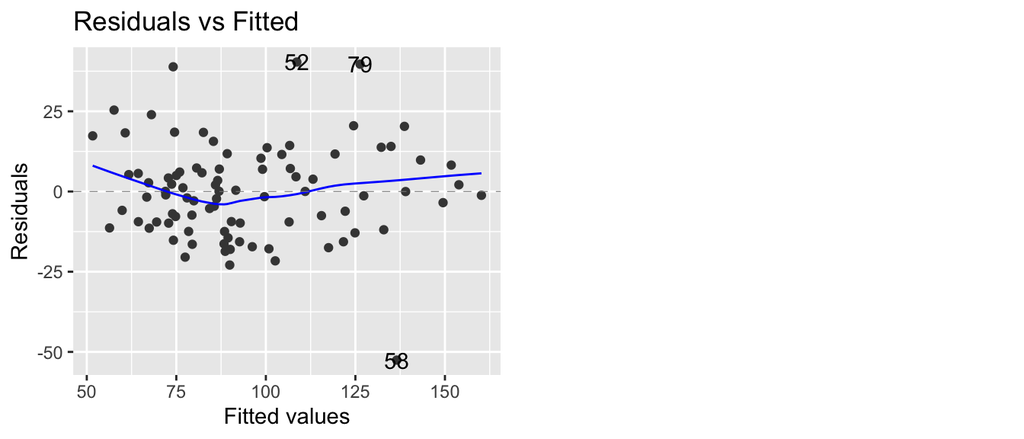

```r
library(ggfortify)
autoplot(mod,1)
```

📈 Here, **[P1]** is validated.

**[P2]** **The $\epsilon_i$ are homoskedastic.**.

To check that the residuals are homoskedastic (identical variance), observe the plot of *standardized residuals* $\widehat r\in[X]^\perp$ against the fitted values $\widehat Y\in[X]$. If we observe, in **Scale-Location plot**:

- A scatter plot which is centred, aligned around 1, and without any structure, then we are satisfied. In other words, if the blue line is approximately horizontal and close to 1 (on the scale!) and if the residuals are generally uniformly distributed around this line, then **[P2]** is validated.
- On the other hand, if we observe some sort of structure, we have reason to believe that the model is not homoskedastic.

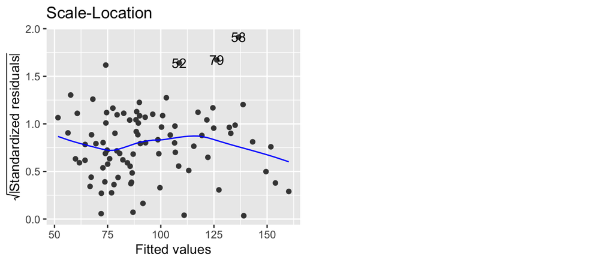

```r
autoplot(mod,3)
```

💡 If it is challenging to validate this hypothesis graphically, we also have the **Breusch-Pagan** test available to make a decision.

$$\mathcal{H}_0: \,\text{"Errors are
homoscedastic"} \ vs \ \mathcal{H}_1: \,\text{"Errors are
heteroscedastic"}$$

```r
library(car)
ncvTest(mod)
```

```
## Non-constant Variance Score Test
## Variance formula: ~ fitted.values
## Chisquare = 2.970944, Df = 1, p = 0.084772
```

📈 Here, **[P2]** is validated both graphically and by the test at the 5% significance level, with a $p$-value greater than 5%.

**[P3]** **The $\epsilon_i$ are uncorrelated.**.

To satisfy hypothesis **[P3]**, it should be that
$$\text{Cov}(\epsilon_t, \epsilon_{t-s}) = 0, \ \forall t, \ \forall s
\neq 0$$
which, in the context of the Gaussian linear model, translates to the independence of residuals. **Although this independence can only be guaranteed by experimental design, we can perform tests to check for autocorrelation in the residuals.** Consider here, the Durbin-Watson.

**[Autocorrelation of order $k$]** :
$$\rho_k = \frac{\text{Cov}(\epsilon_t,
\epsilon_{t-k})}{\sqrt{\text{Var}(\epsilon_t) \cdot
\text{Var}(\epsilon_{t-k})}}$$
where $\epsilon=(\epsilon_1, \ldots, \epsilon_n)^\top$ denotes the residuals.

**Durbin-Watson Test** ($H_0 : \rho_1 = 0$): Primarily used to detect **first-order autocorrelation**.

```r
set.seed(0)
durbinWatsonTest(mod)
```

```
##  lag Autocorrelation D-W Statistic p-value
##    1      0.04519213      1.905021   0.562
##  Alternative hypothesis: rho != 0
```

📈 **[P3]** is validated.

**[P4]** **The $\epsilon_i$ are Gaussian.**.

The **Normal Q-Q plot** is a way of validating that the residuals are normally distributed (*i.e.* the plot of the quantiles of the estimated residuals against the quantiles of a theoretical normal distribution).

- If the points fall approximately along a straight line ($y = x$), then the data are approximately normally distributed. Deviations from this line indicate deviations from normality.

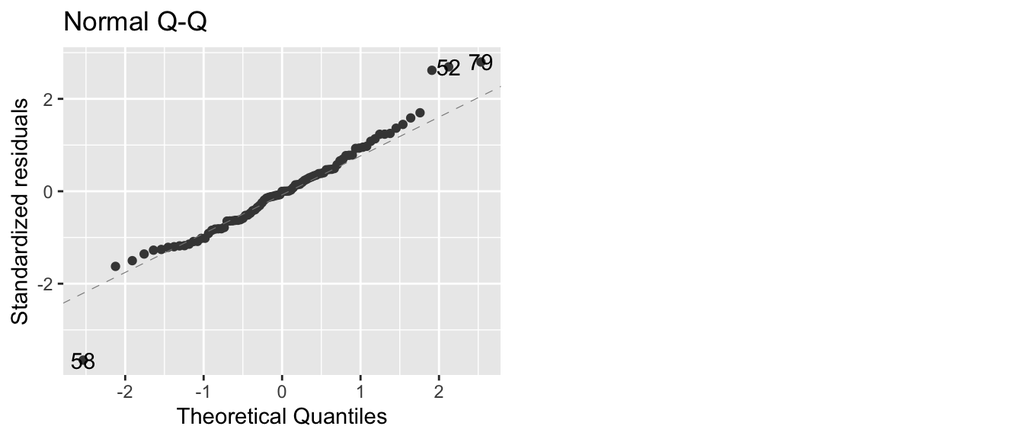

```r
autoplot(mod,2)
```

💡 We also have the **Shapiro** test available to make a decision.
$$\mathcal{H}_0: \,\text{"Errors are normally
distributed"} \ vs \ \mathcal{H}_1: \,\text{"Errors are not
normally distributed"}$$

```r
shapiro.test(residuals(mod))
```

```
##
##  Shapiro-Wilk normality test
##
## data:  residuals(mod)
## W = 0.96674, p-value = 0.02205
```

📝 Note however that assumption **[P4]** can be relaxed: if the number of observations $n$ is large, we can use asymptotic properties of the estimators and tests.

# 3. Selection Model

## 3.1. Generalization performance

Given a training sample $(x_i,Y_i)_{i=1}^n$, we want to predict futur value of $Y$.

- Set a family of model $\mathcal{F}$. Here $\mathcal{F}=\{x^\top\beta,\beta\in\mathbb{R}^p\}$.
- Pick $\widehat f\in\mathcal{F}$ based on the training set. Here $\widehat f(x)=\widehat y=x^\top\widehat\beta$ where $\widehat\beta=(X^\top X)^{-1}X^\top Y$, where $X$ denotes the *design* matrix.
- Asses the accuracy of the model $\widehat f$ on the new observations (test sample)

⚠️ When modeling, it is essential to find the right balance between a model that is too simplistic, which fails to capture all the nuances in the data (*underfitting*), and a model that is too complex, which fits the training data too precisely but loses generality on new data (*overfitting*). Striking this balance ensures that the model **generalizes well to unseen data**, thus ensuring robust performance.

**[Generalization property]** A good model should predict futur value correctly. Let $(X,Y)$ $\mathbb{R}^{p}\times\mathbb{R}$-random vecteur, we define the generalization risk
$$R(\widehat f)=\text{E}\|Y-\widehat
f(X)\|^2=\sigma^2+bias^2(\widehat f)+ \text{Tr}(\text{Var}(\widehat f))$$

📝 Here $R(\widehat f)=\text{E}\|Y-\widehat f(X)\|^2=\sigma^2+bias^2(\widehat f)+ \sigma^2p$

📝 The risk is **not directly computable** since the law $(X,Y)$ is unknown.

**[Empirical risk]**

For $\widehat f$, we can estimate $R(\widehat f)$ from a **Test sample** $(X_t,Y_t)_{t=1,\cdots,T}$

$$\widehat R(\widehat f)=\frac
1T\sum_{t=1}^T\left(Y_t-\widehat f(X_t)\right)^2$$

📌 The graph illustrates the evolution of the model’s performance as a function of its complexity, showing how performance on both the training set (*Train*) and the test set (*Test*) changes as the model complexity increases. Typically, the **goal is to find a balance where the model fits the training data well without compromising its ability to generalize to new, unseen data**. This balance is crucial for avoiding underfitting or overfitting, thereby ensuring optimal model performance.

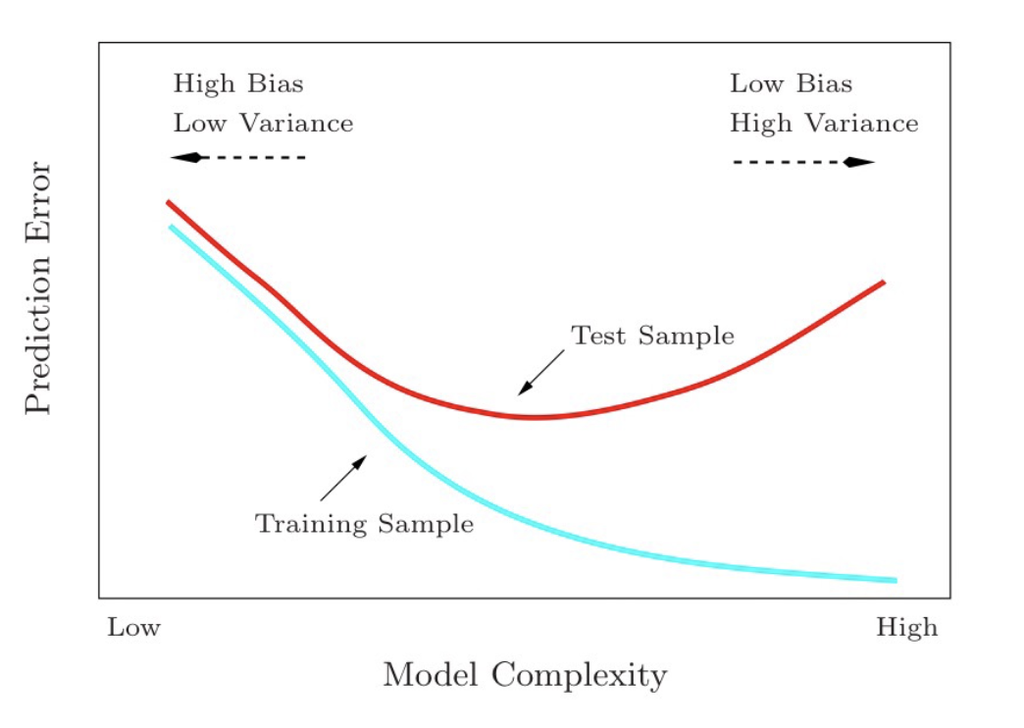

🤔 When does it make sense to **use a low variance biased estimator** ?

To illustrate it, let us consider the following example. We assume the model
$$Y=\beta_1X_1+\beta_2X_2+\epsilon=X\beta+\epsilon, \quad (M1)$$
where - $X=[X_1\,\,X_2]$ is a $n\times 2$ matrix of rank 2 - $\beta=(\beta_1,\beta_2)^\top \in\mathbb{R}^2$ $s.t.$ $\beta_2\not=0$. - Let $\widehat\beta=(X^\top X)^{-1}X^\top Y$, the OLSE calculate from the model $(M1)$, an unbiased estimator.

**Is the variable $X_2$ useful ?** Let us study the case $\beta_2=0$ (even if it is false), and look for when to omit an explanatory variable can be advantageous in terms of risk. Let define the following model
$$Y=X_1\beta_1+\epsilon$$
and the associated OLSE estimator $\widetilde\beta_1=(X_1^\top X_1)^{-1}X_1^\top Y$ of $\beta_1$ where **$Y$ is defined by the model $(M1)$**. Then, $\widetilde\beta=(\widetilde\beta_1,0)^\top$ is a biased estimator.

**[Proposition 1]** In the previous context, $\forall\beta\in\mathbb{R}^2$
$$\text{E}[\|\hat\beta-\beta\|^2]-\text{E}[\|\widetilde\beta-\beta\|^2]\geq
\sigma^2\frac{\|X_1\|^2}{D}-\beta_2^2\left(1+\frac{(X_1^\top
X_2)^2}{\|X_1\|^4} \right ),$$
where $D$ denote the determinant of the matrix $(X^\top X)$.

*Proof.* Will be done in the tutorial.$\square$

📝 This result does not contradict the Gauss-Markov theorem, because $\widetilde\beta$ is biased.  
📝 By introducing (for $\beta_2\neq 0$ and small enough) a slightly biased estimator with a lower variance, the quadratic risk is improved. For estimation (and therefore prediction), it is important to avoid models that are too complex.

## 3.2. Impacts of High Correlation Between Variables

Let define $G=\frac 1n X^\top X$, the Gram matrix. Consider the following regression linear model $Y=X\beta+\epsilon$, such that $\epsilon\sim\mathcal{N}(\boldsymbol{0}_n,\sigma^2\mathbf{I}_n)$. By Gauss-Markov theorem, the OLSE is the best **linear unbiased** estimator such that
$$\text{Var}(\widehat \beta)=\sigma^2 (X^\top
X)^{-1}=\sigma^2\frac{G^{-1}}{n}.$$
$$Y=X\beta+\epsilon, \
\epsilon\sim\mathcal{N}(\boldsymbol{0}_n,\sigma^2\mathbf{I}_n)$$

⚠️ Estimating $\beta$ is an inverse problem whose difficulty is measured by the condition number depending on the eigenvalues of $G$ :
$$\frac{\lambda_{\max}(G)}{\lambda_{\min}(G)}:=\kappa(G)>0$$

- If $\kappa(G)$ is small : $G$ is well-conditioned. This guarantees a good performance of the OLSE.
- If $\kappa(G)$ is large : $G$ is said to be ill-conditioned and the OLSE performs poorly.
  - **Strongly correlated covariates implies that $G$ is ill-conditioned and we may need to use other estimators than OLSE.**
  - Large $p$ increases complexity of the model but may cause numerical instability and/or overfitting.

**Multicollinearity Issues** The numerical variables in your model are highly correlated, which can lead to several issues:

📝 **Sensitivity to Small Changes in the Data** When independent variables are highly correlated, it means they contain almost the same information. The model struggles to distinguish the effect of each variable individually because they *“move”* together. Consequently, if the data change slightly (even a small sample or a minor modification of values), the estimates of the variable coefficients can change disproportionately.  
📝 **Extremely Large Coefficients** Since the model has difficulty attributing a unique contribution to each correlated variable, it compensates by assigning very high coefficients to some of them to adjust the relationship with the dependent variable. These high coefficients do not necessarily reflect a true relationship between the variables and make the model less robust and reliable.  
📝 **Reversed Signs of Coefficients** Sometimes, the model’s sensitivity to data leads to situations where a coefficient, which should normally be positive or negative according to the expected relationship with the dependent variable, changes sign. This happens because the correlated variables *“compete”* to explain the same portion of variance in the dependent variable, resulting in unreliable (*peu/pas fiable*) estimates.  
📝 **Impact on Interpretation** With very large or reversed-sign coefficients, it becomes difficult to understand which variable actually affects the dependent variable and in which direction. This complicates the interpretation and decision-making based on the model.  
📝 **Increase in Standard Errors and High p-values** Multicollinearity increases the standard errors of the estimated coefficients. The standard error measures the precision with which a coefficient is estimated. When this error is high, it means the model has greater uncertainty about the true value of the coefficient. Consequently, the *p*-values associated with the significance tests of the coefficients increase because the precision of the estimates decreases. This distorts statistical tests, making some coefficients statistically insignificant (due to higher p-values), even if these variables have a real effect on the dependent variable. In other words, multicollinearity can mask the true importance of variables in the model.

**In Summary, multicollinearity makes coefficient estimation unstable because the model cannot properly allocate contributions between variables that contain redundant information, leading to extreme or inconsistent results.**

**Ⓡ** In our `Ozone` example, the regressors are strongly correlated! Display the correlation plot.

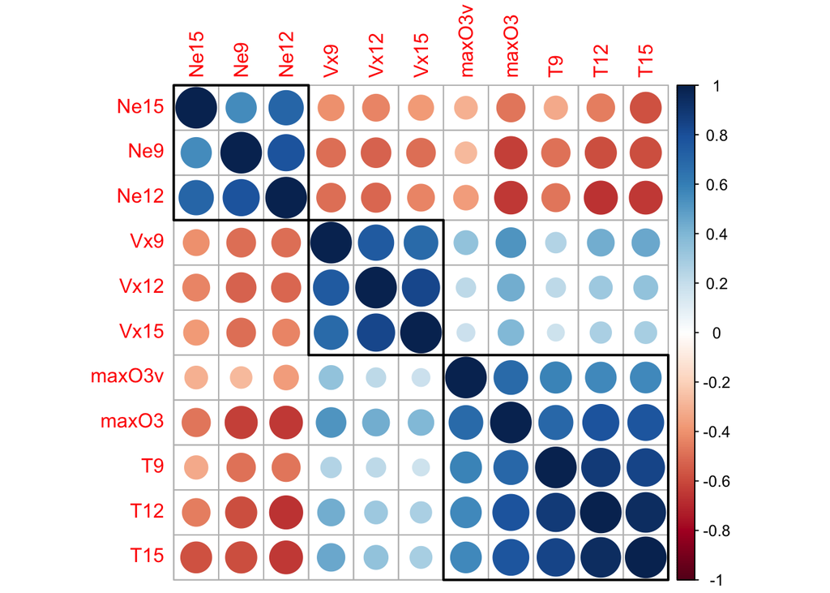

```r
library(dplyr)
library(corrplot)
correlation_matrix<-cor(Ozone)
corrplot(correlation_matrix, order = 'hclust',addrect = 3)
```

**Interpretation**

The `corrplot` function from the `corrplot` library provides a **visual representation of the correlation matrix** for numeric variables only. Each cell in the plot represents the correlation between a pair of variables.

**Color interpretation**

- **Darker blue** = strong positive correlation,
- **Darker red** = strong negative correlation,
- **Lighter colors** (blue or red) = weak or no correlation.

**Rectangles (Clustering)**

- The argument `addrect = 3` means you are adding **3 rectangles** around clusters of variables that have similar correlation patterns. This is useful for visualizing groups of variables that tend to correlate with each other.
- The `order = 'hclust'` argument uses **hierarchical clustering** to order the variables, making it easier to identify blocks of variables with similar correlation patterns.

**For further exploration.** If you want to explore pairwise relationships beyond correlations (e.g., for both numeric and categorical variables), the `ggpairs()` function from the `GGally` package can provide scatter plots, correlations, density plots and more detailed pairwise visualization

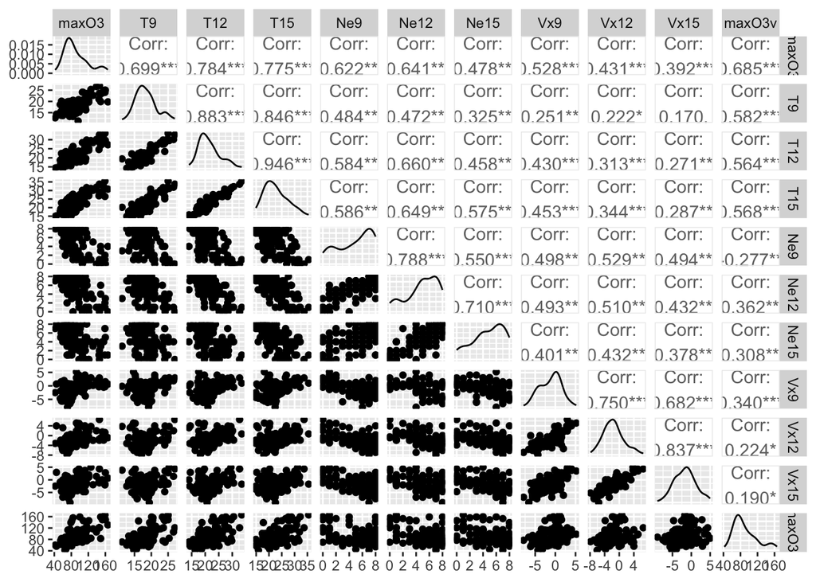

```r
library(GGally)
ggpairs(Ozone)
```

# 4. Criteria

Selecting a set of exploratory variables for a model can be relatively straightforward when comparing two specific models. For this, we need to evaluate them using criteria.

We will focus on the following criteria:

- Tests between nested models
- $R^2$ and adjusted $R^2_a$
- Mallows’ $C_p$
- AIC (Akaike Information Criterion)
- BIC (Bayesian Information Criterion)

Nevertheless, the process becomes more complex when choosing among multiple models.

- **No Natural Order Among Variables.** There is no inherent ranking or natural order among the variables, making the selection process less intuitive.
- **Numerous Possible Models.** The number of potential models can be substantial. For example, with 8 potential variables (excluding the intercept, which is always included), the number of possible models is given by the formula $\sum_{j=0}^8 C_j^8 = 2^8 = 256$ models to consider.

In the next section, we will introduce a step-by-step method to address this problem.

**Notations**

- Let $p=q+1$ be the number of explanatory variables, including the intercept $\mathbf{1}_n$: $X = (\mathbf{1}_n, X_1, \ldots, X_q)$. Consider the framework of linear regression models:
  $$Y = X\beta + \epsilon, \quad \text{rank}(X) = p, \quad \epsilon \sim
  \mathcal{N}(\boldsymbol{0}_n, \sigma^2 \mathbf{I}_n).$$
- Denote $[m]$ as any model of size $m$, where $m = \text{card}([m])$. For any model $[m]$, define:
  $$\text{RSS}(m) = \|Y - P_m Y\|^2,$$
  where $P_m$ is the projection matrix onto the space spanned by the variables in model $[m]$.

### Fisher test for nested models.

Consider the linear model $Y = X\beta + \epsilon$ where $\epsilon \sim \mathcal{N}(\boldsymbol{0}_n, \sigma^2 \mathbf{I}_n)$ and $X$ is full rank. Let $\alpha \in (0,1)$. We want to test
$$\mathcal{H}_0: \text{the model is } [m_0] \subset [m_1] \quad
\text{versus} \quad \mathcal{H}_1: \text{the model is } [m_1].$$
The test statistic
$$T = \frac{\text{RSS}(m_0) - \text{RSS}(m_1)}{\text{RSS}(m_1)} \times (n
- m_1)\sim \large{\text{F}}_{m_1-m_0,n-m1}\quad\text{under }
\mathcal{H}_0$$

💡 Then for Fisher test, we select the model $[m_1]$ if $[m_0] \subset [m_1]$ and
$$\{T >q^{\large{\text{F}}_{m_1-m_0,n-m1}}_{1-\alpha}\}$$

*Proof.* Applying Nested theorem or we can prove

$$\begin{eqnarray}
T &=& \frac{\text{RSS}(m_0) - \text{RSS}(m_1)}{\text{RSS}(m_1)}
\times (n - m_1)=\frac{\|Y - P_{m_0} Y\|^2 - \|Y - P_{m_1} Y\|^2}{\|Y -
P_{m_1} Y\|^2} \times (n - m_1)=\frac{\|P_{m_1} Y- P_{m_0} Y\|^2 }{\|Y -
P_{m_1} Y\|^2} \times (n - m_1)\\
&=&\frac{\|P_{m_1|m_O} Y\|^2 }{\| P_{m_1^\perp} Y\|^2} \times (n
- m_1)=\frac{\|P_{m_1|m_O} Y\|^2/(m_1-m_0)}{\| P_{m_1^\perp}
Y\|^2/(n-m_1)}\\
&=&\frac{\|P_{m_1|m_O} \xi\|^2/(m_1-m_0) }{\| P_{m_1^\perp}
\xi\|^2/(n-m_1)} =\frac{\|P_{m_1|m_O} (\xi/\sigma)\|^2/(m_1-m_0) }{\|
P_{m_1^\perp} (\xi/\sigma)\|^2/(n-m_1)}\sim
\large{\text{F}}_{m_1-m_0,n-m1}\quad\text{under } \mathcal{H}_0
\end{eqnarray}$$

📝 It should be remembered that for the Fisher test, the criterion for two models can only be compared if one model contains the other (nested models).

### The determination coefficient $R^2$

It is recalled that,for a model $[m]$ of size $m$
$$R^2(m)=1-\frac{\text{RSS}(m)}{\text{TSS}}.$$

💡 Then for $R^2$, we select the model $[m_1]$ if
$$R^2(m_1)\geq R^2(m_0)\iff m_1\geq
m_0$$

📝 In general, we do not use the $R^2$ as a selection criterion because it will always increase with the number of variables.  
📝 Used to compare two models with the same number of variables.

### The adjusted determination coefficient $R^2_a$

It is recalled that,for a model $[m]$ of size $m$
$$R^2_a(m)=1-\frac{(n-1)(1-R^2(m))}{n-m}=1-\frac{\text{RSS}(m)}{n-m}\times\frac{(n-1)}{\text{TSS}}.$$

💡 Then for $R_a^2$, we select the model $[m_1]$ if
$$R^2_a(m_1)\geq R^2_a(m_0)$$

📝 This helps to correct the disadvantages of the $R^2$ coefficient.

### The $C_p$ of Mallows

📝 For all model $[m]$, we denote $\widehat Y_m=P_mY$.  
📝 It is recalled that $\text{RSS}(m)=\|P_mY-Y\|^2=\|P_{m^\perp}Y\|^2$  
📝 For any model $[m]$, the **mean squared error (MSE)** of $\widehat Y_m$ is $\text{E}[\|\widehat Y_m-X\beta\|^2]$.

⚠️ Note that $\text{RSS}(m)=\|P_mY-Y\|^2 \neq \|P_mY-X\beta\|^2$ as $X\beta$ not necessarly belongs to $[m]$

**[$C_p$ of Mallows]** Let $[m]$ be any model. The Mallows criterion associated with $[m]$ is defined by:
$$C_p(m)=\frac{\text{RSS}(m)}{\widehat\sigma^2}-n+2m.$$

**[Proposition 2]** **We can show that**

(a.) $\text{E}[\text{RSS}(m)]=\text{E}[\|\widehat Y_m-Y\|^2]=\|(\mathbf{I}-P_m)X\beta\|^2+(n-m)\sigma^2$.  
(b.) $\text{E}[\|\widehat Y_m-X\beta\|^2]=\|(\mathbf{I}-P_m)X\beta\|^2+m\sigma^2.$  
(c.) $\text{E}[C_p(m)\widehat\sigma^2]=\text{E}[\|\widehat Y_m-X\beta\|^2].$

*Proof.* Will be proved in lecture class.

📝 **Unbiased estimator of the mean quadratic error:** We deduce from (c.) that $C_p(m)\widehat\sigma^2$ is an unbiased estimator of the unknown mean quadratic prediction error $\text{E}[\|\widehat Y_m-X\beta\|^2]$.

💡 Then for $C_p$, we select the model $[m_1]$ if
$$C_p(m_1)\leq C_p(m_0)$$

**Discussion.**

📌 The mean squared error (MSE) serves as an **effective criterion** for evaluating the performance of the estimator $\widehat Y_m$. In other words, selecting an optimal model indexed by $m$ can be viewed as the problem of minimizing the following quantity:
$$m\longmapsto\text{E}[\|\widehat Y_m-X\beta\|^2].$$
Unfortunately, this quantity depends on the unknown parameter $\beta$. We have at our disposal *an unbiased estimator* of the MSE. We could then minimize $\quad m\longmapsto C_p(m)\widehat\sigma^2.\quad$ Since $\widehat\sigma^2$ does not depend on the model, it is natural, especially when trying to estimate $X\beta$ to minimize $\quad m\longmapsto C_p(m).$

📌 **A penalized criterion.** We defined the $C_p$ of Mallows criterion as follows
$$C_p(m)\widehat\sigma^2=\text{RSS}(m)+2m\widehat\sigma^2-n\widehat\sigma^2:=\text{RSS}(m)+\text{pen}(m).$$
When studying the classic $R^2$, it appeared that the more variables were added, the more the $\text{RSS}$ decreased: $m$ increases $\Rightarrow \text{RSS}(m)$ decreases. Adding a penalty $\text{pen}(m):=2m\widehat\sigma^2$ to the $\text{RSS}(m)$ in the criterion is an alternative way to the adjusted $R^2$ to counterbalance this effect: $m$ increases $\Rightarrow \text{pen}(m)$ increases}. We say that we **penalize the big models**.

📌 **Adding useless variables to the real model.** Set that the *“real”* model denoted by $[m^*]$ is included in the model $[m_0]$, then
$$X\beta=P_{m_0}X\beta\Leftrightarrow
X\beta-P_{m_0}X\beta=\boldsymbol{0}_n.$$
The equation $(a.)$ then becomes : $\text{E}[\text{RSS}(m_0)]=\text{E}[\|\widehat Y_{m_0}-Y\|^2]=(n-m_0)\sigma^2$ and we have $\text{RSS}(m_0)\approx (n-m_0)\widehat\sigma^2$.

The equations $(b.)$ and $(c.)$ give then: $\text{E}[C_p(m_0)\widehat\sigma^2]=\text{E}[\|\widehat Y_{m_0}-X\beta\|^2]=m_0\sigma^2.$ Therefore, $C_p(m_0)\approx m_0.$

Thus, if we add useless variables (increases $m_0$) to the true model (included in $[m_0]$), then $\text{RSS}(m_0)\approx (n-m_0)\sigma^2$ will not significantly decrease compared to the $C_p(m_0)\approx m_0$ which will increase more significantly.

📌 **Forgetting important variables to the real model.** If the “real” model $[m^*]$ is not fully included in $[m_0]$ then
$$X\beta\neq P_{m_0}X\beta\Leftrightarrow X\beta-P_{m_0}X\beta=C.$$
So with the same reasoning as before we have: note $c:=\|C\|^2$

(a.) $\text{E}[\text{RSS}(m_0)]=\text{E}[\|\widehat Y_{m_0}-Y\|^2]=c+(n-m_0)\sigma^2$.  
(b.) $\text{E}[\|\widehat Y_{m_0}-X\beta\|^2]=c+m_0\sigma^2.$  
(c.) $\text{E}[C_p(m_0)\widehat\sigma^2]=\text{E}[\|\widehat Y_{m_0}-X\beta\|^2].$

We have then $\text{RSS}(m_0)\approx (n-m_0)\widehat\sigma^2+C\quad\text{ et }C_p(m_0)\approx m_0 +c$. In this case, $C_p(m_0)>m_0$.

**To resume**

- If we add useless variables to the “real” model, then $C_p(m_0)\approx m_0.$
- If we forget important variables to the “real” model, then $C_p(m_0)\approx m_0 +c$ where $c>0$.

So if beyond the problem of estimating $X\beta$, we are interested, by the detection of the good variables, we will be interested in models $[m_0]$ such that $C_p(m_0)\leq m_0$.

📌 It should be noted that the previous interpretations are only true if the choice of the model (selection of the optimal $[m]$) is independent of the data (computation of $\widehat Y_m=P_mY$), so we must cut the sample in 2:

- A sample for the *learning* to compute $\widehat Y_{m}$ for all $[m]$.
- Another sample for *validation* to select $[m_ {optimal}]$.

### AIC/BIC criteria

✍ In our setting, the model $[m]$ that maximizes the maximized likelihood on $m$ is the model that minimizes
$$m\longmapsto
\text{RSS}(m).$$

📝 We have seen that minimizing the $\text{RSS}$ is not necessarily the best thing to do because it amounts to taking the largest model ($p=n=m$).  
📝 As for the $C_p$ of Mallows, we want to add a (positive) penalty to penalize the big models.

**[Definition]AIC/BIC]** The AIC of a model $[m]$ is defined by
$$\text{AIC}(m)=n\log\left(\frac{\text{RSS}(m)}{n}\right)+2m.$$

The BIC of a model $[m]$ is defined by
$$\text{BIC}(m)=n\log\left(\frac{\text{RSS}(m)}{n}\right)+\log (n)\times
m.$$

📝 We select the model $[m]$ that minimizes
$$m\longmapsto
\text{AIC}(m)\,\,\text{ or }\,\,m\longmapsto \text{BIC}(m)$$
📝If $n>7$ ($\Rightarrow\log (n)>2$), the penalty term $m \log(n)$ in the BIC criterion becomes larger than the term $2m$ in the AIC criterion. This means that, for models with large $n$, BIC tends to select simpler models than AIC because it imposes a greater penalty on model complexity.

💡 Then, we select the model $[m_1]$ if
$$\left\{\begin{array}{ll}
\text{AIC}(m_1)\leq \text{AIC}(m_0)\\
\text{BIC}(m_1)\leq \text{BIC}(m_0)
\end{array}\right.$$

# 5. Step-by-step method

🙂 **Advantages** : better interpretability, improve prediction performance.

😢 **Disadvantages** : Do not test all possible combinations (Global minimum is not guaranteed.) Greedy algorithm, may provide a suboptimal model for correlated predictors.

Three famous step-by-step methods (intercept is alawys included) are :

- **Forward selection**
- **Backard selection**
- **Stepwise selection/both selction**

📝Under **R** the function `stepAIC`of the `library(MASS)`.  
📝 The command `k=log(n)` has to be added if we want to use BIC criterion (AIC is by default).  
📝 The command `k=2` has to be added if we want to use $C_p$ mallows criterion.

**Ⓡ** Declare our full model `mod` and the model reduced to the intercept `mod0`

```r
mod0<-lm(maxO3~1,data=train)
mod<-lm(maxO3~.,data=train)
```

## 5.1. Forward selection

**Ⓡ** Compute the forward selection with the function `stepAIC` of the `library(MASS)`

```r
library(MASS)
mod_forw<-stepAIC(mod0, maxO3~T9+T12+T15+Ne9+Ne12+Ne15+Vx9+Vx12+Vx15+maxO3v,data=train,trace=T,direction=c('forward'))
```

```
## Start:  AIC=603.32
## maxO3 ~ 1
##
##          Df Sum of Sq   RSS    AIC
## + T12     1     45529 30967 524.83
## + T15     1     44454 32042 527.87
## + T9      1     39581 36915 540.47
## + maxO3v  1     32983 43514 555.11
## + Ne9     1     30996 45501 559.08
## + Ne12    1     30917 45580 559.23
## + Vx9     1     22494 54002 574.32
## + Vx12    1     18378 58118 580.86
## + Ne15    1     17254 59242 582.57
## + Vx15    1     15637 60860 584.96
## <none>                76496 603.32
##
## Step:  AIC=524.83
## maxO3 ~ T12
##
##          Df Sum of Sq   RSS    AIC
## + maxO3v  1    6561.7 24406 505.64
## + Vx9     1    2791.5 28176 518.42
## + Ne9     1    2430.1 28537 519.56
## + Vx15    1    2093.5 28874 520.60
## + Vx12    1    1984.8 28982 520.94
## + Ne12    1    1428.1 29539 522.63
## + Ne15    1     976.9 29990 523.98
## + T15     1     933.6 30034 524.11
## <none>                30967 524.83
## + T9      1     229.6 30738 526.17
##
## Step:  AIC=505.64
## maxO3 ~ T12 + maxO3v
##
##        Df Sum of Sq   RSS    AIC
## + Ne9   1    3812.4 20593 492.52
## + Vx9   1    2200.0 22206 499.23
## + Vx12  1    1992.6 22413 500.06
## + Vx15  1    1927.8 22478 500.32
## + Ne12  1    1658.8 22747 501.37
```

[output cut: 14 more lines]

```
## + Ne15  1     21.88 20571 494.43
## + T9    1     15.05 20578 494.46
## + Ne12  1      8.25 20585 494.49
##
## Step:  AIC=489.52
## maxO3 ~ T12 + maxO3v + Ne9 + Vx9
##
##        Df Sum of Sq   RSS    AIC
## <none>              19468 489.52
## + T15   1    67.028 19401 491.21
## + T9    1    48.546 19419 491.30
## + Vx15  1    31.481 19436 491.38
## + Vx12  1    17.409 19450 491.44
## + Ne15  1     2.213 19466 491.51
## + Ne12  1     0.017 19468 491.52
```

📈Here, we select the following model.

```r
mod_forw
```

```
##
## Call:
## lm(formula = maxO3 ~ T12 + maxO3v + Ne9 + Vx9, data = train)
##
## Coefficients:
## (Intercept)          T12       maxO3v          Ne9          Vx9
##     19.9406       2.4482       0.3707      -2.8073       1.6397
```

📈While with criterion BIC, we select the following model

```r
n<-length(train$maxO3)
mod_forw_BIC<-stepAIC(mod0, maxO3~T9+T12+T15+Ne9+Ne12+Ne15+Vx9+Vx12+Vx15+maxO3v,data=train,trace=F,k=log(n),direction=c('forward'))
mod_forw_BIC
```

```
##
## Call:
## lm(formula = maxO3 ~ T12 + maxO3v + Ne9 + Vx9, data = train)
##
## Coefficients:
## (Intercept)          T12       maxO3v          Ne9          Vx9
##     19.9406       2.4482       0.3707      -2.8073       1.6397
```

## 5.2. Backard selection

**[Backard selection]** We stat the “biggest” model whose intercept. At each step, a regressor/variable is removed to the model, the one which improves the chosen criterion. We stop when the criterion can not be improved by removing a new regressor/variable.

**Ⓡ** Compute the backward selection with the function `stepAIC` of the `library(MASS)`

```r
library(MASS)
mod_back<-stepAIC(mod,~.,trace=T,direction=c("backward"))
```

```
## Start:  AIC=500.64
## maxO3 ~ T9 + T12 + T15 + Ne9 + Ne12 + Ne15 + Vx9 + Vx12 + Vx15 +
##     maxO3v
##
##          Df Sum of Sq   RSS    AIC
## - Vx12    1       3.3 19279 498.65
## - Vx15    1      19.6 19295 498.73
## - Ne12    1      35.8 19311 498.80
## - T9      1      37.9 19313 498.81
## - Ne15    1      54.4 19330 498.89
## - T12     1      93.7 19369 499.07
## - T15     1     116.2 19392 499.17
## - Vx9     1     423.9 19699 500.57
## <none>                19275 500.64
## - Ne9     1    1215.7 20491 504.08
## - maxO3v  1    5916.5 25192 522.46
##
## Step:  AIC=498.65
## maxO3 ~ T9 + T12 + T15 + Ne9 + Ne12 + Ne15 + Vx9 + Vx15 + maxO3v
##
##          Df Sum of Sq   RSS    AIC
## - Vx15    1      16.8 19296 496.73
## - Ne12    1      32.7 19311 496.80
## - T9      1      34.6 19313 496.81
## - Ne15    1      53.7 19332 496.90
## - T12     1     110.2 19389 497.16
## - T15     1     113.7 19392 497.18
## <none>                19279 498.65
## - Vx9     1     507.1 19786 498.96
## - Ne9     1    1232.8 20512 502.17
## - maxO3v  1    6123.2 25402 521.20
##
## Step:  AIC=496.73
## maxO3 ~ T9 + T12 + T15 + Ne9 + Ne12 + Ne15 + Vx9 + maxO3v
##
##          Df Sum of Sq   RSS    AIC
## - Ne12    1      33.4 19329 494.88
## - T9      1      46.5 19342 494.94
## - Ne15    1      51.0 19346 494.97
## - T12     1      99.8 19395 495.19
```

[output cut: 36 more lines]

```
## <none>                19401 491.21
## - T12     1     609.0 20010 491.96
## - Vx9     1    1040.7 20441 493.86
## - Ne9     1    2539.6 21940 500.16
## - maxO3v  1    6995.9 26396 516.62
##
## Step:  AIC=489.52
## maxO3 ~ T12 + Ne9 + Vx9 + maxO3v
##
##          Df Sum of Sq   RSS    AIC
## <none>                19468 489.52
## - Vx9     1    1125.4 20593 492.52
## - Ne9     1    2737.8 22206 499.23
## - T12     1    3688.4 23156 502.96
## - maxO3v  1    7206.2 26674 515.55
```

📈Here, we select the following model

```r
mod_back
```

```
##
## Call:
## lm(formula = maxO3 ~ T12 + Ne9 + Vx9 + maxO3v, data = train)
##
## Coefficients:
## (Intercept)          T12          Ne9          Vx9       maxO3v
##     19.9406       2.4482      -2.8073       1.6397       0.3707
```

📈 While with criterion BIC, we select the following model

```r
library(MASS)
stepAIC(mod,~.,trace=F,k=log(n),direction=c("backward"))
```

```
##
## Call:
## lm(formula = maxO3 ~ T12 + Ne9 + Vx9 + maxO3v, data = train)
##
## Coefficients:
## (Intercept)          T12          Ne9          Vx9       maxO3v
##     19.9406       2.4482      -2.8073       1.6397       0.3707
```

## 5.3. Stepwise selection/both selection

**[Both selection]** This is the same method as the Forward selection method, except that at each step, a regressor/variable present in the model can be challenged (removed or added).

**Ⓡ** Compute the both selection with the function `stepAIC` of the `library(MASS)`

```r
library(MASS)
mod_both<-stepAIC(mod0, maxO3~T9+T12+T15+Ne9+Ne12+Ne15+Vx9+Vx12+Vx15+maxO3v,data=train,trace=T,direction=c('both'))
```

```
## Start:  AIC=603.32
## maxO3 ~ 1
##
##          Df Sum of Sq   RSS    AIC
## + T12     1     45529 30967 524.83
## + T15     1     44454 32042 527.87
## + T9      1     39581 36915 540.47
## + maxO3v  1     32983 43514 555.11
## + Ne9     1     30996 45501 559.08
## + Ne12    1     30917 45580 559.23
## + Vx9     1     22494 54002 574.32
## + Vx12    1     18378 58118 580.86
## + Ne15    1     17254 59242 582.57
## + Vx15    1     15637 60860 584.96
## <none>                76496 603.32
##
## Step:  AIC=524.83
## maxO3 ~ T12
##
##          Df Sum of Sq   RSS    AIC
## + maxO3v  1      6562 24405 505.64
## + Vx9     1      2792 28176 518.42
## + Ne9     1      2430 28537 519.56
## + Vx15    1      2093 28874 520.60
## + Vx12    1      1985 28982 520.94
## + Ne12    1      1428 29539 522.63
## + Ne15    1       977 29990 523.98
## + T15     1       934 30034 524.11
## <none>                30967 524.83
## + T9      1       230 30738 526.17
## - T12     1     45529 76496 603.32
##
## Step:  AIC=505.64
## maxO3 ~ T12 + maxO3v
##
##          Df Sum of Sq   RSS    AIC
## + Ne9     1    3812.4 20593 492.52
## + Vx9     1    2200.0 22205 499.23
## + Vx12    1    1992.6 22413 500.06
## + Vx15    1    1927.8 22478 500.32
```

[output cut: 24 more lines]

```
## Step:  AIC=489.52
## maxO3 ~ T12 + maxO3v + Ne9 + Vx9
##
##          Df Sum of Sq   RSS    AIC
## <none>                19468 489.52
## + T15     1      67.0 19401 491.21
## + T9      1      48.5 19419 491.30
## + Vx15    1      31.5 19436 491.38
## + Vx12    1      17.4 19450 491.44
## + Ne15    1       2.2 19466 491.51
## + Ne12    1       0.0 19468 491.52
## - Vx9     1    1125.4 20593 492.52
## - Ne9     1    2737.8 22206 499.23
## - T12     1    3688.4 23156 502.96
## - maxO3v  1    7206.2 26674 515.55
```

📈Here, we select the following model

```r
mod_both
```

```
##
## Call:
## lm(formula = maxO3 ~ T12 + maxO3v + Ne9 + Vx9, data = train)
##
## Coefficients:
## (Intercept)          T12       maxO3v          Ne9          Vx9
##     19.9406       2.4482       0.3707      -2.8073       1.6397
```

👀While with criterion BIC, we select the following model

```r
library(MASS)
stepAIC(mod0, maxO3~T9+T12+T15+Ne9+Ne12+Ne15+Vx9+Vx12+Vx15+maxO3v,data=train,trace=F,k=log(n), direction=c('both'))
```

```
##
## Call:
## lm(formula = maxO3 ~ T12 + maxO3v + Ne9 + Vx9, data = train)
##
## Coefficients:
## (Intercept)          T12       maxO3v          Ne9          Vx9
##     19.9406       2.4482       0.3707      -2.8073       1.6397
```

## 5.4. Discussion

Here, the three methods select the same model using the AIC and BIC criteria.

**Ⓡ** Compute theis model and the full model by a Fisher test

```r
mod_0 <- mod_forw
mod_1 <- mod

anova(mod_0, mod_1)
```

|  | Res.Df | RSS | Df | Sum of Sq | F | Pr(>F) |
| --- | --- | --- | --- | --- | --- | --- |
| 1 | 84 | 19467.69 | NA | NA | NA | NA |
| 2 | 78 | 19275.39 | 6 | 192.3051 | 0.1296973 | 0.9922336 |

📈`p-value`is larger thant 5%, we can’t reject $\mathcal{H}_0$, we prefer for this test the smallest model. We can compare the RMSE on the Test sample.

**[RMSE]**

Let $(X,Y)=\{(x_i,y_i)\}_{i=1,\cdots,n}$ be the train sample and $\widehat \beta(X,Y)$ the OLSE computed on the train sample. Then, we can define the **Root Mean Squared Error (RMSE)**

- On the **train sample** $(X,Y)=\{(x_i,y_i)\}_{i=1,\cdots,n}$

$$RMSE=\|Y-X \widehat
\beta(X,Y)\|_n$$

- On the **test sample** (generalization performance) $(X_T,Y_T):=\{(X_t,Y_t)\}_{t=1,\cdots,T}$
  $$RMSE=\|Y_T-X_T \widehat
  \beta(X,Y)\|_T$$

where $\|u\|_q=\sqrt{\frac{1}{q}\sum_{j=1}^qu_j^2}$ for $u\in\mathbb{R}^q$.

```r
library(Metrics)
mod<-lm(maxO3~.,data=train)
RMSE_full_train= rmse(train$maxO3,predict(mod, newdata = train))
RMSE_full_test= rmse(test$maxO3,predict(mod, newdata = test))

RMSE_0_train= rmse(train$maxO3,predict(mod_0, newdata = train))
RMSE_0_test= rmse(test$maxO3,predict(mod_0, newdata = test))



RMSE_train<-c(RMSE_full_train,RMSE_0_train)
RMSE_test<-c(RMSE_full_test,RMSE_0_test)
RMSE<-rbind.data.frame(RMSE_train,RMSE_test)
names(RMSE)<-c('mod','mod_0')
row.names(RMSE)<-c('Train','Test')
RMSE
```

|  | mod | mod_0 |
| --- | --- | --- |
| Train | 14.716568 | 14.789797 |
| Test | 9.007425 | 8.553392 |

# 6. Outliers

## 6.1. Discussion

**[Outliers]**

An outlier is an atypical observation such that the response variable $Y$ and/or predictors $X_j$ appear to behave differently from the majority of observations.

📝 **Outliers may occur for various reasons**

- obvious cases: measurement errors, data transcription errors,…*Example: a customer recorded to be 400 years old; a 1 year old baby running the 100m in 10 seconds…*
- Adversarial error to scuttle the analysis.
- outlierssometimes reveal a particular phenomenon that may be different from the model followed by the majority of observations. *Example: gene expression in Cancer patient as compared to healthy individuals.*

📝 **In the regression setting**, an typical values (*outliers*) can occur in three main ways :

- in the response $Y$ but not in the predictors $X_j$,
- in the predictors $X_j$ but not in the response variable $Y$,
- in both $Y$ and $X$.

#### **A. Outlier in the $Y$-direction but not in the predictors $X$**

*Exemple* Scatter plot of the toy dataset $Y=(Y_1,\ldots,Y_n)^\top$. Boxplot reveals the outliers.

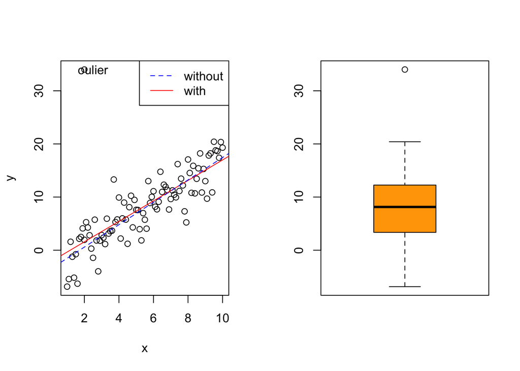

**Question** what is the impact of this outlier on this regression model? We plot the two LSE regression lines

- **with** the outlier: $y=1.9254378x +-2.2701754$,
- **without** the outlier: $y=2.1061473x +-3.6203342$.

📈 **For THIS scenario**

- the outlier has only a small effect on the estimation. Indeed, removing this point slightly changes the regression line (least squares line).
- This type of atypical observations () has an impact on the estimation of $\sigma^2$ so on the residuals $\widehat\epsilon=Y-\widehat Y$.
- The **regression outliers** can be detected by a residuals analysis.

#### **B. Outlier out of domain point**

*Isolated observation* has atypical values in the predictors $X_{ij}$. It means that the values $\left(X_{ij}\right)_j$ of the observation $i$ are relatively far from all the value $\left(X_{i'j}\right)_j$ of the other observations $i'\neq i$. We say this point is out of domain.

*Exemple* Let us consider an other toy example.

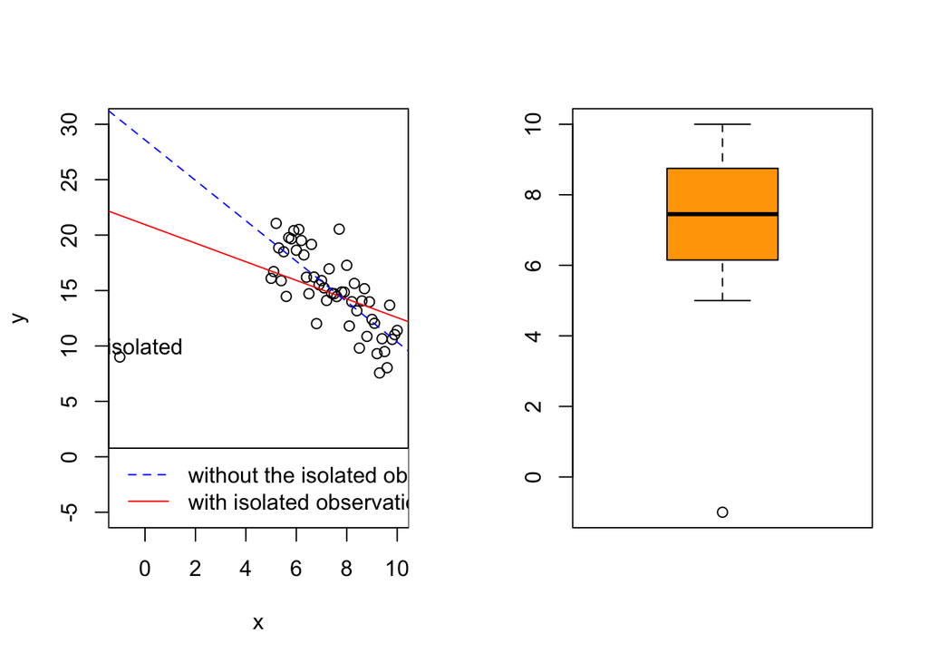

**Question** what is the impact of this outlier on this regression model? We plot the two LSE regression lines

- **with** the outlier: $y=-0.8391409x +20.9530211$,
- **without** the outlier: $y=-1.8231533x +28.5839412$.

📈 **For THIS scenario**

- The isolated observation has a significant impact on the estimation of $\beta$. Indeed, removing this point significantly changes the LSE regression line.
- The isolated observation is quite far from the regression line. It does not follow the general linear trend of the majority of observations.
- Such of points are called **high leverage point**. Statisticians are always wary of such points. Sometimes they do not significantly change the estimation of $\beta$ and sometimes they do.
- **Leverage points** can be detected by a multivariate detection study of the *“leverage effect”.*

## 6.2. Regression outliers

The model may fail to correctly predict $Y_i$, and then its standardized residual (or studentized residual) is large. Such an observation is called a regression outlier.

**[Regression outlier]**

A **regression outlier** is an observation $(x_i^T,Y_i)$ such that the associated studentized residual $t_i^*$ is high:
$$|t_i^*|>
t_{n-p-1,1-\alpha/2}.$$

📝📝 Note that in theory, $\alpha\%$ of the data are outliers.  
📝 In practice, we use $\alpha=5\%$, and for a large enough sample (larger than $30 + p$), $t_{n-p-1,1-\alpha/2} \approx 2$. We are actually looking for $(x_i^T,Y_i)$ for which $t_i^*$ is **well** outside the confidence band in the $i \longmapsto t_i^*$ plot.  
📝 Explaining the presence of these outliers can be difficult. They may be caused by measurement errors or by a change in the population.  
📝 It is recommended to pay attention to these points and check whether they have too much influence on the calculation of $\widehat{\beta}$ and $\widehat{\sigma}^2$.

These observations can be identified on the *Studentized-plot*.

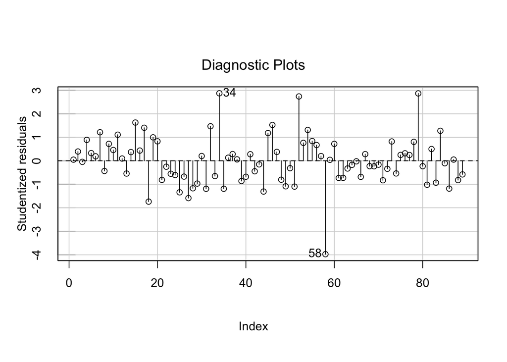

```r
library(car)
influenceIndexPlot(mod_0,vars="Studentized")
```

## 6.3. Outliers with strong leverage on themselves

Consider the orthogonal projector $P_X$ onto $[X]$ : $P_X=X(X^\top X)^{-1}X^\top$. We defined
$$\widehat Y=X\widehat \beta=P_XY \ \text{where} \ P_W=[h_{ij}]_{1\leq
i\leq n \\1\leq j\leq n} \ \text{is also called the hat matrix}$$

**[Proposition 3]**

Note $h_{ij}=(P_X)_{ij}$, the entries of $P_X$. The trace of $P_X$ is equal to :
$$Tr(P_X)=\sum_{i=1}^nh_{ii}=p.$$
Moreover, for all $i=i,\cdots,n$ and for all $j\not=i$,

- $0\leq h_{ii}\leq 1,\quad -\frac{1}{2}\leq h_{ij}\leq \frac{1}{2}.$
- If $h_{ii}=1$ then $h_{ij}=0$.

💡 **Impact of the $i$-observation on its own estimation**

The predicted values $\widehat y_i$ can be written as a linear combination of all the observations
$$\widehat y_i=\sum_{j=1}^nh_{ij}y_j=h_{ii}y_i+\sum_{j\neq
i\\j=1}^nh_{ij}y_j$$

**[Leverage effect on themselves]** An observation $i$ is called a **leverage point** if $h_ {ii}> s$, where

- $s=2p/n$ according to Hoaglin & Welsch (1978),
- $s=3p/n$ for $p>6$ and $(n-p)>12$ according to Velleman & Welsch (1981),
- $s=1/2$ according to Huber& Welsch (1981).

📝 Without necessarily being an **regression outlier** (residuals analysis), leverage points are atypical points in explanatory variables.  
📝 If an observation is such that $h_ {ii}> s$, it influences its own estimate.

If an observation has a large influence on its own estimation $\widehat{Y_i}$, it is said to have a strong leverage effect on its own estimation: $\Rightarrow$ In practice, the hat-*value* > 0.5. These observations can be identified on the *Hat-plot*.”

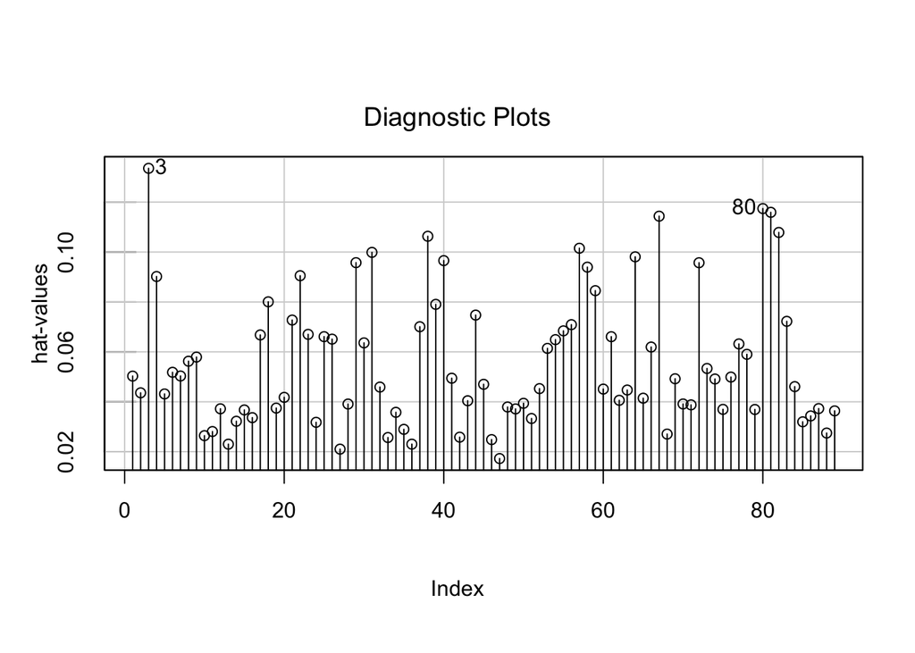

```r
influenceIndexPlot(mod_0,vars="hat")
```

📈 **For the òzone`dataset**, none of the observations has a strong impact on its own estimation.

⚠️ It is important to detect and analyze them: *Do they come from measurement errors or from a population of a different nature ?* We may not systematically eliminate them. **But it does not necessarily affect the overall model**, that is, the estimate of $\beta$.

## 6.4. Outliers with strong leverage on the model

An analysis of the influence (leverage effect) of an observation is based on the idea of comparing the adjustment with and without this observation. Note that it should be done for each observation in the dataset.

**Estimation of $\beta$ without the $i$-observation $(x_i,Y_i)$**

📌 The index $"(-i)"$ means “without the $i$-observation”. For example, the matrix $X_{(-i)}$ is the $(n-1)\times p$ matrix corresponding to the matrix $X$ without the $i$-$th$ line.
📌 Denote by $\widehat{\beta}_{(-i)}$ the OLSE computed from the dataset without the $i$-observation:
$$\widehat\beta_{(-i)}=\left(X_{(-i)}^\top \,
X_{(-i)}\right)^{-1}X^\top_{(-i)} \, Y_{(-i)}.$$

**[LSE prediction for the $i$-observation]** is defined by the following quantity
$$\widehat
Y_i^P=x_i^\top \widehat\beta_{(-i)}.$$
**[The associated prediction error]** is defined by the following quantity
$$Y_i-\widehat Y_i^P.$$

📝 If the $i$-observation is not too influential, we expect that the residues in both cases to be close:
$$Y_i-\widehat Y_i \approx Y_i-\widehat Y_i^P.$$
📝 If not, the $i$-observation deserves special attention.
📝 These two quantities are related to the orthogonal projector $P_X$.

**[Theorem 2]** Assume $X$ is full rank and –. Then we have for all $i=1,\cdots,n$
$$Y_i-\widehat Y_i=(1-h_{ii})(Y_i-\widehat Y_i^P),$$
where $h_{ii}$ denote the $i$-$th$ diagonal element of $P_X$.

*Proof.* Let this be an exercise for you to do on your own.$\square$

📝 $h_{ii}$ “corresponds” in a way to the distance of $x_i$ from the gravity center $\bar x$ of the scatter plot $x_i$. **The Leverage $h_{ii}$’s tell us which observations are isolated from the rest of the sample**.  
📝 If $|hij|$ is large then observation $j$ has a strong influence on the prediction $\widehat y_i$ and on its own predition for $i=j$.  
📝 $\widehat Y_i$ is entirely determined by $Y_i$ as soon as $h_{ii}=1$.  
📝 If $h_{ii}=0$, $Y_i$ has no influence on $\widehat Y_i$.  
📝 The prediction error ($Y_i-\widehat Y_i$) and the associated prediction error ($Y_i-\widehat Y_i^P$) are equal for $h_{ii}=0$.

💡 While the residuals analysis identifies atypical values related to the explained variable $Y$, the analysis of $P_X$ detects atypical values related to predictors $X_j$. But **does such of point impact the estimation of $\beta$ (cook distance) ?** The **Cook’s distance** combines these two analyzes. It is essentially a standardized distance measure that describes the change in the $\beta$ estimator when we remove the observation $i$.

**[Cook’s distance]**

For all $i$, the Cook’s distance of the observation $(x^T_i,Y_i)$ is given by the following formula :
$$D_i=\frac{1}{p\widehat\sigma^2}(\widehat\beta_{(-i)}-\widehat\beta)^T(X^TX)(\widehat\beta_{(-i)}-\widehat\beta)$$
where $\widehat\beta_{(-i)}$ is the estimation of $\beta$ in the model without the $i$-$th$ observation.

📝 With this definition, the Cook’s distance can be seen as a criterion measuring the leverage effect of the $i$-observation on the model (so on $\beta$) : distance between the 2 models (with and without the $i$-observation).

**[Proposition 4]**:

The Cook’s distance of the observation $(x^T_i,Y_i)$ satisfies
$$D_i=\frac{h_{ii}}{p\widehat\sigma^2(1-h_{ii})^2}(Y_i-\widehat
Y_i)^2=\frac{h_{ii}}{p(1-h_{ii})}t_i^2$$
where $h_{ii}$ is the $i$-$th$ diagonal element of the orthogonal projector $P_X$ and $t_i$ is the standardized residual associated to the observation $i$.

*Proof.* Let this be an exercise for you to do on your own.$\square$

📝 With this proposition, The Cook’s distance can be seen as a criterion measuring both the character of the $i$-observation (measured by its standardized residual)  
📝 The Cook’s distance can be large if the standardized residues are large or if the levers are large (or if both are large).

**Leverage effect on the model** A high value of Cook’s distance suggests that observation $i$ has a high influence (in practice compared to 1).

- $D_i<1$ suggests small impact of $i$-observation.
- $D_i>1$ suggests high impact of $i$-observation.

🧠 **What to do with outliers? Should we manage, remove, or keep them?**

These outliers can be identified on the *Cook’s-plot*.”

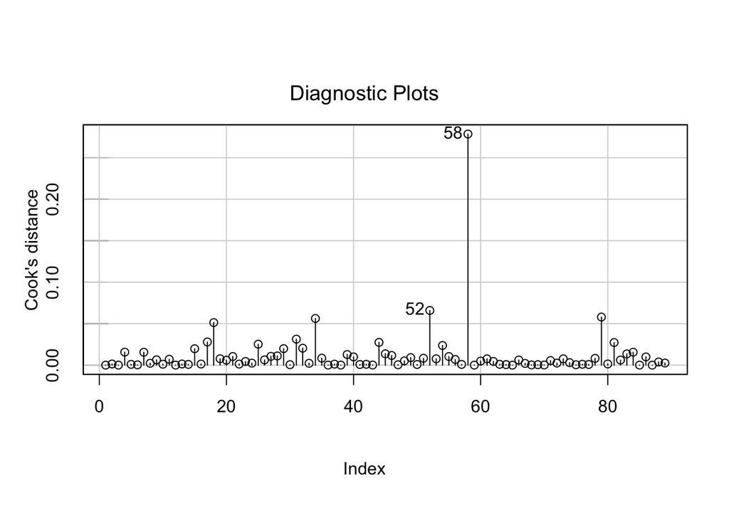

```r
influenceIndexPlot(mod_0,vars="cook")
```

📈 **For the òzone`dataset**, none of the observations has a Cook’s distance larger than 1.

📝 Note also that you can get this plot with `àutoplot(mod_0,1:4)`

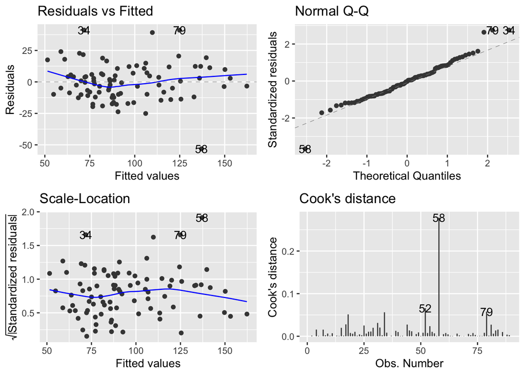

```r
library(ggfortify)
autoplot(mod_0,1:4)
```

## 6.5. Handling of outliers

The **studentized residuals** value of $t^*_i$ measures how far observation $i$ deviates from the prediction in terms of standard deviation
$$t^*_i=\frac{\widehat\epsilon_i}{\widehat\sigma_{(-i)}\sqrt{1-h_{ii}}}.$$
If $|t^*_i|$ is very large, it suggests that the observation is potentially an outlier:

**[Testing outilers]**

The `outlierTest()` function in R (from the `car` package) is designed to identify **outliers** in the context of a linear regression model. It is based on the analysis of **studentized residuals**, taking into account the influence of other data points in the model
$$\mathcal{H}_0 \ : \ \text{No outliers
exist.} \qquad vs \qquad \mathcal{H}_1 \ : \ \text{Observation i is
an outlier if }t^*_i \ \text{is significant.}$$

The **Bonferroni test** is used to adjust the p-values obtained from individual tests on each observation. When identifying outliers, each observation $i$ is tested to see if it is an outlier based on its studentized residual $t_i$. To account for multiple tests (one for each observation), the *p-value* is adjusted using the **Bonferroni correction.** It is a robust tool for detecting influential or aberrant observations in linear regression models.

✅ The idea behind the **Bonferroni adjustment** is to correct for multiple comparisons by reducing the chance of false positives. In a dataset with $n$ observations, $n$ tests are performed to identify an outlier, increasing the likelihood of finding one simply by chance. The Bonferroni correction divides the significance threshold $\alpha$ by the number of tests $n$. Thus, an adjusted Bonferroni *p-value* is calculated by:
$$p_v^{\text{unadjusted}} = p_v \times n$$

The `outlierTest()` returns observations with significantly small p-values after adjustment, indicating that these observations are outliers.

```r
library(car)
outlierTest(mod_0)
```

```
##     rstudent unadjusted p-value Bonferroni p
## 58 -3.974282          0.0001499     0.013341
```

📈.

The observation `58`has the smallest *Bonferroni p-value*, with a `pvalue`smaller than 5%, therefore the observation `58`is an outlier.

📌 `rstudent`=-3.9742823 the value $t^*_{58}$, it indicates that this observation is approximately 3.97 standard deviations below the prediction. In a normal distribution, this suggests that the observation is rare and could be considered an outlier.  
📌 `unadjusted p-value`=1.4989805^{-4} : This is the **unadjusted p-value** associated with testing whether the observation `58` is an outlier. It represents the probability that this observation is an outlier **under the null hypothesis** (i.e., assuming no outliers in the data). It means that there’s about a **0.01499 % of chance** of observing a residual this extreme under the null hypothesis. This would suggest that `58` could be an outlier, if no correction for multiple testing was applied.  
📌`Bonferroni p`=0.0133409 After applying the Bonferroni correction, the observation is still considered a significant outlier at the 5% level, but it is no longer considered a significant outlier at the 1% level.

✍ Note that you can display 4 plot with `influenceIndexPlot(mod_0)`

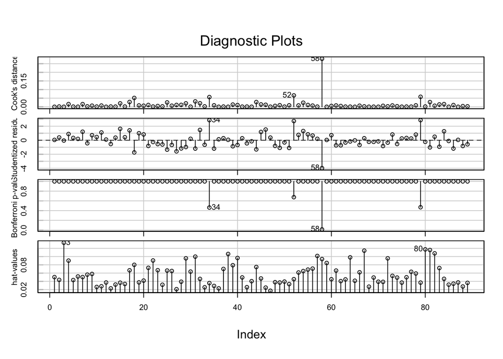

```r
influenceIndexPlot(mod_0)
```